# Testing the Equality of Normal Distributed and Independent Groups’ Means Under Unequal Variances by doex Package

Mustafa Cavus

Eskisehir Technical University

Berna Yazıcı

Eskisehir Technical University

2021-01-14

Abstract

In this paper, we present the [*doex*](https://CRAN.R-project.org/package=doex) package contains the tests for equality of normal distributed and independent group means under unequal variances such as Cochran F, Welch-Aspin, Welch, Box, Scott-Smith, Brown-Forsythe, Johansen F, Approximate F, Alexander-Govern, Generalized F, Modified Brown-Forsythe, Permutation F, Adjusted Welch, B2, Parametric Bootstrap, Fiducial Approach, and Alvandi Generalized F-test. Most of these tests are not available in any package. Thus, *doex* is easy to use for researchers in multidisciplinary studies. In this study, an extensive Monte-Carlo simulation study is conducted to investigate the performance of the the tests for equality of normal distributed group means under unequal variances

in terms of Type I error probability and penalized power. In the case of Type I error probability of the compared tests are different, the penalized power is used which allows fair power comparisons. In this way, we conclude the performance of the tests by taking into account two possible errors in hypothesis testing.

# Introduction

Testing equality of normal distributed and independent groups’ means is a basic analysis in statistics and related fields. The Fisher’s F-test is a powerful test to do this analysis with the assumptions of variance homogeneity, normality, and statistical independency. Violation of the variance homogeneity assumption is a commonly encountered statistical problem in a variety of application areas such as agriculture, pharmacy, and biostatistics. There is number of methods improved because of the negative effect of the violation of variance homogeneity assumption on the performance of Classical F-test in terms of Type I error probability and power. These tests are, Cochran F (CF), Welch-Aspin (WA), Welch (WE), Box (BX), Scott-Smith (SS), Brown-Forsythe (BF), Johansen (JF), Approximate F (AF), Alexander-Govern (AG), Generalized F (GF), Modified Brown-Forsythe (MBF), Permutation F (PF), Adjusted Welch (AW), B2, Parametric Bootstrap (PB), Fiducial Approach (FA) and Alvandi et al. Generalized F (AGF) test, chronologically. The fact that the high number of methods in the literature raises the problem of choosing the most appropriate method for researchers.

There are many articles to investigate the performance of the tests for equality of normal distributed and independent group means under unequal variances in the literature. However, only some of the tests are included in these studies. The results of these studies help researchers to solve the problem of choosing the appropriate method for their work. (Gamage and Weerahandi 1998) compared the size performance of the GF test and four widely used procedures: CF, BF, and Welch test in case of deviation from normality. The highly skewed Gamma distributions and Gamma distributions with shapes close to being normal are considered. While the GF was found to have size not exceeding the intended level, as heteroscedasticity becomes severe the others were found to have poor size performance. (Hartung, Argac, and Makambi 2002) compared the CF, C, W, BF, MBF, AF, and AW tests under normal populations, balanced-unbalanced sample sizes and an increasing number of populations. None of the tests considered is uniformly dominating the others. The BF and the W test perform well over a wide range of parameter configurations, the MBF test by Mehrotra keeps generally the level, but other tests may also perform well, depending on the constellation of the parameters under study. The W test becomes liberal when the sample sizes are small and the number of populations is large. They propose a modified version of Welch’s test that keeps the nominal level in these cases. With the understanding that methods are unacceptable if they have Type I error rates that are too high, only the testing procedure associated with the MBF test can be recommended, the modified Welch test can also be recommended. (Argac 2004) constructed a systematic pattern in simulations of the tests for equality of normal distributed and independent group means under unequal variances. Classical F, Cochran, Welch, modified Welch, Brown-Forsythe, modified Brown-Forsythe, and approximate F test considered are divided into two groups, Cochran-Welch type tests and the Brown-Forsythe type tests. There seems to be considerably higher variability in the power of C-W type tests in the balanced case. In the unbalanced case, there does not appear to be a huge difference between the power of the different tests. (Sadooghi-Alvandi, Jafari, and Mardani-Fard 2012) proposed a new GF test and compared it with GF, PB, Welch, and Cochran test in an extensive Monte-Carlo simulation study. According to results, it controls the Type I error probability better and its power closed to the others. (Gokpinar and Gokpinar 2012) compared the Type I error probability and power of CF, BF, GF, PB, and W test under different variance heterogeneities and effect sizes for three and five groups. Their results indicate that PB is the best control Type I error probability and has the highest power. In addition to these articles, the scope of the other articles are not comprehensive in the literature ((Hartung, Argac, and Makambi 2002), (Lee and Ahn 2003), (Li, Wang, and Liang 2011), (Mutlu et al. 2017)). A comprehensive Monte-Carlo simulation study is conducted under normal distribution in this article in order to fill this gap. Especially, the penalized power is used which allows fair power comparisons when the Type I error probabilities are different. In this way, we conclude the performance of the tests by taking into account two possible errors in hypothesis testing.

Another problem experienced by the researchers is most of these tests are not available in any R package. However, some R packages contain the tests for equality of normal distributed and independent group means under unequal variances, [*asbio*](https://CRAN.R-project.org/package=asbio) by (Aho 2018), [*coin*](https://CRAN.R-project.org/package=coin) by (Hothorn et al. 2008), [*lawstat*](https://CRAN.R-project.org/package=lawstat) by (Hui, Gel, and Gastwirth 2008), [*onewaytests*](https://CRAN.R-project.org/package=onewaytests) by (Dag, Dolgun, and Konar 2018), [*welchADF*](https://CRAN.R-project.org/package=welchADF) by (Villacorta 2017), [*WRS2*](https://CRAN.R-project.org/package=WRS2) by (Mair and Wilcox 2018). These packages contain only the Brunner-Dette-Munk, Permutation F, Kruskal-Wallis, Brown-Forsythe, Alexander-Govern, James Second Order, Welch test. In particular, the performance of the tests such as the GF, PB, FA, and AGF test by Monte-Carlo simulations prevents the easy use of these tests. Clearly, a package should contain these tests. We propose the package *doex* provides the tests for equality of normal distributed group means under unequal variances which previously have not been implemented in any R package such as AF, AGF, B2, FA, JF, MBF, MW, PB, and PF. Also, it consists of the modified Generalized F-test (MGF) which is proposed by (M. Cavus, Yazici, and Sezer 2017) to test the equality of group means under heteroscedasticity and non-normality caused by outliers. It is a useful procedure for non-normal distributed groups and (M. Cavus, Yazici, and Sezer 2018) showed in a real data application.

The following sections detail the tests for equality of normal distributed and independent group means under unequal variances considered in *doex*. The performance of these tests is investigated in terms of penalized power and Type I error probability. Finally, we conclude with a brief summary and future works.

# Tests for Testing Equality of Normal Distributed Groups’ Means under Unequal Variance

The linear model within the context of a one-way independent group design for testing the equality of groups’ means is given in (@ref(eq:1)) .

$$\label{eq:1}
Y_{ij}=\mu_i+\epsilon_{ij} (\#eq:1)$$

where $Y_{ij}$ is the dependent variable associated with the $i$th observation in the $j$th group for $i= 1, 2, ..., n_i$ and $j= 1, 2, ..., k$. $\mu_i$ is the group mean for the $i$th group, and $\epsilon_{ij}$ is the random error component associated with $Y_{ij}$. The null hypothesis $H_0: \mu_1=\mu_2= ...= \mu_k$ is tested as the Classical F-test assumed that the $\epsilon_{ij}$’s are independent, normally distributed, and have an equal variance $\sigma^2$ for each group of $k$. Type I error probability of Classical F-test inflates and its power decreases in case of the violation of variance homogeneity assumption. There are many procedures improved in the literature to solve this problem. In this section, the tests for equality of normal distributed and independent group means under unequal variances, considered in *doex* and discussed in the Monte-Carlo simulation study, are introduced. These tests are, Alexander-Govern, Alvandi et al. generalized F, Approximate F, Box F, Brown-Forsythe, $B^2$, Cochran F, Fiducial Approach, Generalized F, Johansen, Modified Brown-Forsythe, Adjusted Welch, Parametric Bootstrap, Permutation F, Scott-Smith, Welch, Welch-Aspin test.

## Alexander-Govern (AG) test

(Alexander and Govern 1994) improved a test using the Hill’s normality transformation to the Student’s t variables. Consider $X_{i1}, X_{i2}, ..., X_{in_i} \sim N(\mu_i, \sigma_i^2)$ and the standard deviations of normal groups computed as in (@ref(eq:AG1)).
$$\label{eq:AG1}
S_{\bar{X}_i}= \frac{\sum_{i=1}^k \sum_{j=1}^{n_i}
(X_{ij}-\bar{X}_i)^2}{n_i(n_i-1)} (\#eq:AG1)$$
The weights are computed using the $S_{\bar{X}_i}$ as in (@ref(eq:AG2)).
$$\label{eq:AG2}
wi=\frac{1/S_{\bar{X}_i}^2}{\sum_{i=1}^k
1/S_{\bar{X}_i}^2} (\#eq:AG2)$$
The weight mean is computed using the $w_i$ in (@ref(eq:AG3)).
$$\label{eq:AG3}
\bar{X}^*=\sum_{i=1}^k w_i\bar{X}_i (\#eq:AG3)$$
The values of $t_i=(\bar{X}_i-\bar{X}^*)/S_{\bar{X}_i} \sim t_{n_i-1}$ are transformed using the following transformation.
$$z_i=c+\frac{c^3+3c}{b}+\frac{4c^7+33c^5+240c^3+855c}{10b^2+8bc^4+1000b}$$
where $a=v_i-0.5, c=\sqrt{a ln (1+\frac{t_i^2}{v_i})}$ and $b=48a^2$. The test statistic of AG test is computed as in (@ref(eq:AG4)).
$$\label{eq:AG4}
T_{AG}=\sum_{i=1}^k z_i^2 (\#eq:AG4)$$
The $H_0$ is rejected when $T_{AG}>\chi^2_{(k-1); \alpha}$.

## Alvandi et. al. Generalized F (AGF) test

(Sadooghi-Alvandi, Jafari, and Mardani-Fard 2012) proposed the test statistic in @ref(eq:AGF1) as an alternative of Weerahandi’s Generalized F-test.
$$T_G(S_1^2, S_2^2, ..., S_k^2)=\sum_{i=1}^k
\frac{n_i}{S_i^2}\bar{X}_i-\frac{[\sum_{i=1}^k
n_i\bar{X}_i/S_i^2]^2}{\sum_{i=1}^k n_i/S_i^2}$$

$$\label{eq:AGF1}
T_{AGF}=\sum_{i=1}^k \frac{n_i-1}{U_i}
(\bar{X}_i-q_i\tilde{X})^2 (\#eq:AGF1)$$
where $q_i=\sqrt{\frac{n_i/s_i^2}{\sum_{i=1}^k n_i/s_i^2}}$ and $\tilde{X}=\sum_{i=1}^k q_i \bar{X}_i$. The p-value of AGF test computed using Monte-Carlo simulations with **Algorithm 1**.

**Algorithm 1.** Computation of Monte-Carlo estimate of the AGF test

1. Compute the vectors of $(\bar{x}_1, \bar{x}_2, ..., \bar{x}_k)$ and $(s_1^2, s_2^2, ..., s_k^2)$ for $k$ groups
2. Compute the $T_G$ using the vectors in **Step 1**
3. **for** $j$ in $\{1, ..., r\}$ **do**  
   Generate $U_i \sim \chi^2_{n_i-1}$ random samples Compute the $T_{AGF}$  
   using generated random samples Set the counter $Q_j=1$ when $T_{AGF}>T_G$  
   **end for**
4. Compute the Monte-Carlo estimate of p-value as $\sum_{i=1}^k Q_j/r$

## Approximate F (AF) test

(Asiribo and Gurland 1990) proposed a modification to the F-test as in (@ref(eq:AF1)).
$$\label{eq:AF1}
T_{AF}=N\frac{\sum_{i=1}^k n_i(\bar{X}_i-\bar{X}_{..})^2}{\sum_{i=1}^k
(N-n_i)S_i^2} (\#eq:AF1)$$
where $\bar{X}_{..}=\sum_{i=1}^k \bar{X}_i$ and $N=\sum_{i=1}^k n_i$. The $H_0$ is rejected when $T_{AF}>F_{v1, v2; \alpha}$. The degrees of freedom of the AF test statistic is computed in (@ref(eq:AF2)).
$$\label{eq:AF2}
v_1=\frac{[\sum_{i=1}^k (1-n_i/N)S_i^2]^2}{\sum_{i=1}^k
S_i^4+[\sum_{i=1}^k n_i S_i^2/N]^2-2\sum_{i=1}^k n_i S_i^4/N},
v_2=\frac{[\sum_{i=1}^k (1-n_i/N)^2 S_i^2]^2}{\sum_{i=1}^k
(n_i-1)S_i^4} (\#eq:AF2)$$

## Box (BX) test

(Box 1954) proposed the test statistic in (@ref(eq:BO1)).
$$\label{eq:BO1}
T_{BO}=\frac{N_k}{N(k-1)\sum_{i=1}^k
\frac{(N-n_i)S_i^2}{(n_i-1)S_i^2}} (\#eq:BO1)$$
The $H_0$ is rejected when $T_{BO}>F_{v_1, v_2; \alpha}$ where
$$v_1=\frac{[\sum_{i=1}^k
(N-n_i)S_i^2]^2}{[\sum_{i=1}^k n_i S_i^2]^2+N\sum_{i=1}^k
(N-2n_i)S_i^2},
v_2=\frac{[\sum_{i=1}^k (n_i-1 S_i^2)]^2}{\sum_{i=1}^k
(n_i-1)S_i^+}$$

## Brown-Forsythe (BF) test

(Brown and Forsythe 1974) proposes the following test statistic.
$$T_{BF}=\frac{\sum_{i=1}^k
n_i(\bar{X}_i-X_{..})^2}{\sum_{i=1}^k (1-n_i/N)S_i^2}$$
where $X_{..}=\sum_{i=1}^k \bar{X}_i$ and $N=\sum_{i=1}^k n_i$. The $H_0$ is rejected when $T_{BF}>F_{(k-1), v; \alpha}$. The degrees of fredom of the test statistic computed as in (@ref(eq:BF1)).
$$\label{eq:BF1}
v=\frac{[\sum_{i=1}^k n_i(\bar{X}_i-X_{..})]^2}{\sum_{i=1}^k
\frac{(1-n_i/N)^2 S_i^4}{(n_i-1)}} (\#eq:BF1)$$

## The $B^2$ test

(Ozdemir and Kurt 2006) proposed the following procedure using the Bailey’s normality transformation to the Student’s t variables. Consider $X_{i1}, X_{i2}, ..., X_{in_i} \sim N(\mu_i, \sigma_i^2)$ and the standard deviations of normal groups computed as in (@ref(eq:B21)).
$$\label{eq:B21}
S_{\bar{X}_i}=\frac{\sum_{i=1}^k \sum_{j=1}^{n_i}
(X_{ij}-\bar{X}_i)^2}{n_i(n_i-1)} (\#eq:B21)$$
The weights computed using the $S_{\bar{X}_i}$ as in (@ref(eq:B22)).
$$\label{eq:B22}
w_i=\frac{1/S_{\bar{X}_i}^2}{\sum_{i=1}^k
1/S_{\bar{X}_i}^2} (\#eq:B22)$$
The weighed mean computed using the $w_i$’s as in (@ref(eq:B23)).
$$\label{eq:B23}
\bar{X}^*=\sum_{i=1}^k w_i\bar{X}_i . (\#eq:B23)$$
The values of $t_i=(\bar{X}_i-\bar{X}^*)/S_{\bar{X}_i} \sim t_{n_i-1}$ are transformed using Bailey’s (1980) normality transformation.
$$z_i=\frac{4v_i^2+\frac{5(2z_c^2+3)}{24}}{4v_i^2+v_i+\frac{4z_c^2+9}{12}}\sqrt{v_i
ln(1+\frac{t_i^2}{v_i})} \sim N(0, 1)$$
where $z_c=Z_{\alpha/2} \sim N(0, 1)$ and the test statistic of $B^2$ test computed as in (@ref(eq:B24)).
$$\label{eq:B24}
T_{BK}=\sum_{i=1}^k z_i^2=\sum_{i=1}^k
(\frac{4v_i^2+\frac{5(2z_c^2+3)}{24}}{4v_i^2+v_i+\frac{4z_c^2+9}{12}})^2
. (\#eq:B24)$$
The $H_0$ is rejected when $T_{BK}>\chi^2_{(k-1); \alpha}$.

## Cochran (CF) test

(Cochran 1937) proposes the test statistic in (@ref(eq:CF1)).
$$\label{eq:CF1}
T_C=\sum_{i=1}^k w_i (\bar{X}_i - \sum_{j=1}^k
h_j\bar{X}_j)^2 (\#eq:CF1)$$
where $w_i=n_i/s_i^2$ and $h_i=w_i/\sum_{i=1}^k w_i$. The $H_0$ is rejected when $T_C > \chi^2_{(k-1); \alpha}$.

## Fiducial Approach (FA) test

(Li, Wang, and Liang 2011) proposed the test statistic in (@ref(eq:FA1)).
$$\label{eq:FA1}
T_{FA}=\sum_{i=1}^k t_i^2-\frac{(\sum_{i=1}^k
\frac{\sqrt{n_i}}{S_i}t_i)^2}{\sum_{i=1}^k \frac{n_i}{S_i^2}}
. (\#eq:FA1)$$
The p-value of the FA test can be computed using Monte-Carlo simulations with **Algorithm 2**.

**Algorithm 2.** Computation of Monte-Carlo estimate of the FA test

1. Compute the vectors of $(\bar{x}_1, \bar{x}_2, ..., \bar{x}_k)$ and $(s_1^2, s_2^2, ..., s_k^2)$ for $k$ groups
2. Compute the $T_G$ using the vectors in **Step 1**
3. **for** $j$ in $\{1, ..., r\}$ **do**  
   Generate $Z_i \sim N(0, 1)$ and $U_i \sim \chi^2_{n_i-1}$ random samples  
   Compute the $T_{FA}$ using generated random samples  
   Set the counter $Q_j=1$ when $T_{FA}>T_G$  
   **end for**
4. Compute the Monte-Carlo estimate of p-value as $\sum_{i=1}^k Q_j/r$

## Generalized F (GF) test

(Weerahandi 1995) proposed the test statistic in (@ref(eq:GF1)) using the generalized p-value approach.
$$\label{eq:GF1}
T_{GF}=\sum_{i=1}^k (n_iU_i/v_i^2)\bar{x}_i^2-\frac{[\sum_{i=1}^k
(n_iU_i/v_i^2)\bar{x}_i]^2}{\sum_{i=1}^k
n_iU_i/v_i^2} (\#eq:GF1)$$
where $v_i^2=(n_i-1)S_i^2$. The p-value of GF test can be computed using Monte-Carlo simulations with **Algorithm 3**.

**Algorithm 3.** Computation of Monte-Carlo estimate of the GF test

1. Compute the vectors of $(\bar{x}_1, \bar{x}_2, ..., \bar{x}_k)$ and $(s_1^2, s_2^2, ..., s_k^2)$ for $k$ groups
2. Compute the $T_G$ using the vectors in **Step 1**
3. **for** $j$ in $\{1, ..., r\}$ **do**  
   Generate $U_i \sim \chi^2_{n_i-1}$ random samples  
   Compute the $T_{GF}$ using generated random samples  
   Set the counter $Q_j=1$ when $T_{GF}>T_G$  
   **end for**
4. Compute the Monte-Carlo estimate of p-value as $\sum_{i=1}^k Q_j/r$

## Johansen (JF) test

(Johansen 1980) proposed an approximate solution to the W test as in (@ref(eq:tj)).

$$\label{eq:tj}
T_J=\frac{\sum_{i=1}^k
\frac{\bar{X}_i^2}{S_i^2}-\frac{[\sum_{i=1}^k\bar{X}_i/S_i^2]^2}{\sum_{i=1}^k
1/S_i^2} }{c} (\#eq:tj)$$

where $c=(k-1)+2A-6A/(k+1)$, $v=(k-1)(k+1)/3A$ and $A=\sum_{i=1}^k (1-w_i/w)^2/(n_i-1)$ The $H_0$ is rejected when $T_J > F_{k-1, v; \alpha}$.

## Modified Brown-Forsythe (MBF) test

(Mehrotra 1997) proposed the test statistic in (@ref(eq:MBF1)), which is a modification of BF, to well-performing in case of small sample size.
$$\label{eq:MBF1}
T_{MBF}=\frac{\sum_{i=1}^k n_i(\bar{X}_i-\bar{X}_{..})^2}{\sum_{i=1}^k
(1-n_i/N)S_i^2} . (\#eq:MBF1)$$
where $\bar{X}_{..}=\sum_{i=1}^k \bar{X}_i$ and $N=\sum_{i=1}^k n_i$. The $H_0$ is rejected when $T_{MBF>F_{v_1, v_2; \alpha}}$. The degrees of freedom of the MBF test statistics is computed as in (@ref(eq:MBF2)).
$$\label{eq:MBF2}
v_1=\frac{[\sum_{i=1}^k (1-n_i/N)S_i^2]^2}{\sum_{i=1}^k
S_i^4+(\sum_{i=1}^k n_iS_i^2/N)^2-2\sum_{i=1}^k n_iS_i^4/N}
, v_2=\frac{[\sum_{i=1}^k (1-n_i/N)^2 S_i^2]^2}{\sum_{i=1}^k
\frac{(1-n_i/N)^2S_i^4}{n_i-1}} . (\#eq:MBF2)$$

## Adjusted Welch (AW) test

(Hartung, Argac, and Makambi 2002) proposed an adjustment to the Welch test. The test statistic of adjusted Welch test is computed as in (@ref(eq:AW1)).
$$\label{eq:AW1}
T_W=\frac{\sum_{i=1}^k w_i^* (\bar{x}_i-\sum_{j=1}^k
h_j^*\bar{x}_j)^2}{(k-1)+2\frac{k-2}{k+1}\sum_{i=1}^k
\frac{1}{n_i-1}(1-h_j^*)^2}
. (\#eq:AW1)$$
where $w_i^*=[\frac{n_i}{(n_i-1/n_i-3)s_i^2}]$ and $h_i^*=\frac{w_i^*}{\sum_{i=1}^k w_i^*}$. The $H_0$ is rejected when $T_W>F_{(k-1), v; \alpha}$. The degrees of freedom of the test statistic computed in (@ref(eq:AW2)).
$$\label{eq:AW2}
v=\frac{\frac{k^2-1}{3}}{\sum_{i=1}^k \frac{(1-h_i^*)^2}{n_i-1}}
. (\#eq:AW2)$$

## Parametric Bootstrap (PB) test

(Krishnamoorthy, Lu, and Mathew 2007) proposed a procedure to test the equality of group means under heteroscedasticity.
$$T_G(S_1^2, S_2^2, ...,
S_k^2)=\sum_{i=1}^k \frac{n_i}{S_i^2}\bar{X}_i-\frac{[\sum_{i=1}^k
n_i\bar{X}_i/S_i^2]^2}{\sum_{i=1}^k n_i/S_i^2}$$
Assume $Z_i \sim N(0, 1)$ and $U_i \sim \chi^2_{n_i-1}$ random samples, the test statistic of the PB test is computed as in (@ref(eq:PB2)).
$$\label{eq:PB2}
T_{PB}(S_1^2, S_2^2, ..., S_k^2)=\sum_{i=1}^k \frac{Z_i^2
(n_i-1)}{U_i}-\frac{[\sum_{i=1}^k
\sqrt{n_i}Z_i(n_i-1)/S_iU_i]^2}{\sum_{i=1}^k
n_i(n_i-1)/S_i^2U_i} (\#eq:PB2)$$
The $H_0$ is rejected when $T_{PB}>T_G$. The p-value of PB test is computed using Monte-Carlo simulations with **Algorithm 4**.

**Algorithm 4.** Computation of Monte-Carlo estimate of the PB test

1. Compute the vectors of $(\bar{x}_1, \bar{x}_2, ..., \bar{x}_k)$ and $(s_1^2, s_2^2, ..., s_k^2)$ for $k$ groups
2. Compute the $T_G$ using the vectors in **Step 1**
3. **for** $j$ in $\{1, ..., r\}$ **do**  
   Generate $Z_i \sim N(0, 1)$ and $U_i \sim \chi^2_{n_i-1}$ random samples  
   Compute the $T_{PB}$ using generated random samples  
   Set the counter $Q_j=1$ when $T_{PB}>T_G$  
   **end for**
4. Compute the Monte-Carlo estimate of p-value as $\sum_{i=1}^k Q_j/r$

## Permutation F (PF) test

(Berry and Mielke 2002) proposed the test statistic in (@ref(eq:PF1)) as the permutational alternative of F-test.
$$\label{eq:PF1}
T_{PF}=\frac{(T-N\bar{X}^*)/(k-1)}{(V-T)/(N-k)} (\#eq:PF1)$$
where $T=\sum_{i=1}^k n_i\sum{x}_i^2$, $\bar{X}^*=1/N\sum{n_i\bar{x}_i}$ and $V=\sum_{i=1}^k \sum_{j=1}^{n_i} X_{ij}^2$. The $H_0$ is rejected when $T_{PF}>F_{k-1, N-k; \alpha}$.

## Scott-Smith (SS) test

(Scott and Smith 1971) proposed the test statistic in (@ref(eq:SS1)).
$$\label{eq:SS1}
T_{SC}=\sum_{i=1}^k
\frac{n_i(\bar{X}_i-\bar{X}_{..})^2}{S_i^{*2}} (\#eq:SS1)$$
where $S_i^{*2}=\frac{n_i-1}{n_i-3}S_i^2$. The $H_0$ is rejected when $T_{SC}>\chi^2_{k; \alpha}$.

## Welch (WE) test

(Welch 1951) improved the test statistic in @ref(eq:W1) based on the weighted group variance as an alternative to the F-test under heteroscedasticity.
$$\label{eq:W1}
T_W=\frac{\sum_{i=1}^k w_i(\bar{x}_i-\sum_{i=1}^k
h_j\bar{x}_j)^2}{(k-1)+2\frac{k-2}{k+1}\sum_{i=1}^k
\frac{1}{n_i-1}(1-h_i)^2} (\#eq:W1)$$
where $w_i=n_i/s_i^2$ and $h_i=w_i/\sum_{i=1}^k w_i$. The $H_0$ is rejected when $T_W>F_{(k-1), v; \alpha}$. The degrees of freedom of the Welch test computed as in @ref(eq:W2).
$$\label{eq:W2}
v=\frac{(k^2-1)/3}{\sum_{i=1}^k
\frac{(1-h_i)^2}{n_i-1}} (\#eq:W2)$$

## Welch-Aspin (WA) test

(Aspin 1948) proposed the test statistic in (@ref(eq:WA1)) with a modification to the degrees of freedom of Welch test.
$$\label{eq:WA1}
T_{WA}=\frac{\sum_{i=1}^k
(\bar{X}_i-\bar{X})^2/S_i^2}{(k-1)[1+\frac{2k-2}{k^2-1}\lambda]} (\#eq:WA1)$$
where $\lambda=\sum_{i=1}^k [(1-w_i)^2/w_i]$, $v_1=k-1$ and $v_2=(k^2-1)/3\lambda$. The $H_0$ is rejected when $T_{WA}>F_{v_1; v_2; \alpha}$.

# Using *doex* package

The *doex* package provides to perform several tests for equality of normal distributed and independent distributed group means under unequal variances. These tests are called a function with the initials of their name which are given in the previous sections. In particular, the following tests are not included in any R package or statistical package program: AF, AGF, B2, FA, JF, MBF, MW, PB, and PF. In this section, the examples are given how to use these tests by using doex. After the explanatory data analysis, the variance homogeneity assumption must be checked to move on to the next stage (Noguchi and Gel 2010; Erps and Noguchi 2019). The Levene Test is used to this, and we did not include it in the package is because it is included in many R package such as [*car*](https://CRAN.R-project.org/package=car) by (Fox and Weisberg 2019), [*rstatix*](https://CRAN.R-project.org/package=rstatix) by (Kassambara 2020), *lawstat* by (Gastwirth et al. 2020), [*inferr*](https://CRAN.R-project.org/package=inferr) by (Hebbali 2018). We want to stick with the idea of creating a package that includes tests not included in the CRAN.  
**Example 1:** The data are inputted to the functions with two parts: observations and the group labels. As an example `hybrid` data from Weerahandi (1995) is given in the package. It consists of two parts: `data` are observations and `species` are the labels of species of the corn hybrids.

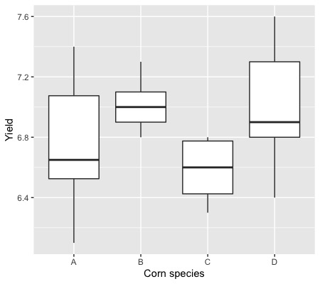

Figure 1: Boxplot of the data in Example 1.

```r
# Call the doex package
> library(doex)
# print hybrid data of Weerahandi (1995)
> hybrid

    data species
 1   7.4       A
 2   6.6       A
 3   6.7       A
 4   6.1       A
 5   6.5       A
 6   7.2       A
 7   7.1       B
 8   7.3       B
 9   6.8       B
 10  6.9       B
 11  7.0       B
 12  6.8       C
 13  6.3       C
 14  6.4       C
 15  6.7       C
 16  6.5       C
 17  6.8       C
 18  6.4       D
 19  6.9       D
 20  7.6       D
 21  6.8       D
 22  7.3       D

# observations of the hybrid data
> hybrid$data
 [1] 7.4 6.6 6.7 6.1 6.5 7.2 7.1 7.3 6.8 6.9 7.0 6.8 6.3 6.4 6.7 6.5 6.8 6.4 6.9 7.6 6.8 7.3

 # group labels of the hybrid data
> hybrid$species
 [1] A A A A A A B B B B B C C C C C C D D D D D
 Levels: A B C D

 # The ggplot2 package can be used to plot the box plot of the data in Figure 1.
> ggplot(hybrid, aes(x = species, y = data)) +
>  geom_boxplot() +
>  ylab("Yield") +
>  xlab("Corn Species")
```

```r
# Look at the summary statistics of the data before using the tests.
# Use psych package to obtain the descriptive statistics of the hybrid data
> library(psych)

# Describe the hybrid data by species using describe.by(.) function
> describe.by(hybrid$data, hybrid$species)

#The output of the describe.by function as follows:

Descriptive statistics by group
group: A
   vars n mean   sd median trimmed  mad min max range skew kurtosis   se
X1    1 6 6.75 0.48   6.65    6.75 0.52 6.1 7.4   1.3 0.11     -1.7 0.19
----------------------------------------------------------
group: B
   vars n mean   sd median trimmed  mad min max range skew kurtosis   se
X1    1 5 7.02 0.19      7    7.02 0.15 6.8 7.3   0.5 0.28    -1.72 0.09
----------------------------------------------------------
group: C
   vars n mean   sd median trimmed mad min max range  skew kurtosis   se
X1    1 6 6.58 0.21    6.6    6.58 0.3 6.3 6.8   0.5 -0.13    -2.02 0.09
----------------------------------------------------------
group: D
   vars n mean   sd median trimmed  mad min max range skew kurtosis   se
X1    1 5    7 0.46    6.9       7 0.59 6.4 7.6   1.2 0.04    -1.84 0.21

# It is seen that the variances of the species are unequal
# Thus we need to use the tests for equality of the group means under unequal variances
#
# Examples of the use of the AF and GF tests on the hybrid data are given in the follows.
# The following code performs the Approximate F-test on the hybrid data.

> library(doex)
> AF(hybrid$data,hybrid$species)

# This function returns a result matrix consists of a test statistic, degrees of freedom,
and p-value of Approximate F-test as follows:

              Test Statistic df1 df2 p-value
Approximate F         1.8538   2  12  0.1943
```

```r
# Following code performs the Generalized F-test.

> library(doex)
> GF(hybrid$data,hybrid$species)

# The p-value of the GF test is computed Monte-Carlo estimates and its size is
# controlled with the rept parameter in the function. It is implemented as
# default rept=10000
# This function returns the p-value of the Generalized F-test as follows:

              p-value
Generalized F  0.0492

# The results of the AF and GF tests are different at the nominal level 0.05.
# It is needed to investigate the performance of these tests in
# a Monte-Carlo simulation study.
```

**Example 2:** This example is provided an external data involves litter weights of mice born from mothers assigned to three different dosage groups and a control. For the low dose group the dose metameter is 5, for the medium dose group it is 50, and for the high dose group it is 500. In here, the problem is testing the equality of mean of litter weights of mice born according to the used dose. The dataset is available in the following repository: https://github.com/mcavs/doex_TheRJournal.

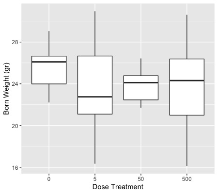

Figure 2: Boxplot of the data in Example 2.

```r
# Print born weight data using the data is given in GitHub repository.

   weight_data dose
1        22.69    0
2        26.59    0
3        28.85    0
4        28.03    0
5        29.05    0
6        23.61    0
7        22.21    0
8        26.81    0
9        26.01    0
10       25.98    0
.   .   .
.   .   .
.   .   .
70       26.31  500
71       30.61  500
72       26.48  500
73       24.31  500
74       27.98  500

# The ggplot2 package can be used to plot the box plot of the data in Figure 2.
> ggplot(born_weight_data, aes(x = dose, y = weight_data)) +
>  geom_boxplot() +
>  ylab("Born Weight (gr)") +
>  xlab("Dose Treatment")
```

```r
# Describe the born weight data by species using describe.by(.) function
> describe.by(born_weight_data$weight_data, born_weight_data$dose)

#The output of the describe.by function as follows:

 Descriptive statistics by group
group: 0
   vars  n  mean   sd median trimmed  mad   min   max range skew kurtosis   se
X1    1 20 25.73 2.02   26.1   25.74 2.43 22.21 29.05  6.84 -0.1    -1.16 0.45
-------------------------------
group: 5
   vars  n  mean  sd median trimmed  mad   min   max range skew kurtosis   se
X1    1 19 23.52 3.9  22.75   23.51 4.28 16.34 30.95 14.61 0.01    -0.97 0.89
-------------------------------
group: 50
   vars  n  mean   sd median trimmed  mad   min   max range  skew kurtosis   se
X1    1 18 23.79 2.83  24.11   23.84 1.92 17.54 29.21 11.67 -0.28     0.03 0.67
-------------------------------
group: 500
   vars  n  mean   sd median trimmed  mad   min   max range skew kurtosis   se
X1    1 17 23.72 4.08  24.31   23.76 3.84 16.13 30.61 14.48 -0.4    -0.91 0.99

# It is seen that the variances of the dose groups may be unequal
# To conclude whether the variance homogenity assumption is valid,
# Levene test is used.

> library(car)
> car::LeveneTest(weight_data ~ dose)

# LeveneTest(.) function returns the test statistic and
# p-value of Levene variance homogeneity test as follows:

Levene's Test for Homogeneity of Variance (center = median)
      Df F value Pr(>F)
group  3  3.3819 0.0229 *
---
Signif. codes:
  0 ‘***’ 0.001 ‘**’ 0.01 ‘*’ 0.05 ‘.’

# The p-value of Levene test is lower than the nominal level 0.05,
# so it is concluded that the variance homogeneity assumption is violated.
# Thus we need to use the tests for equality of the group means under
# unequal variances in doex.

# The GF, AF, and PB are used to conclude there is a significance difference between
# the mean born weight of mice according to used dose group.

> doex::GF(weight_data, dose)

              p-value
Generalized F  0.0331

> doex::AF(weight_data, dose)

              Test Statistic df1 df2 p-value
Approximate F         1.9408   3  57  0.1484

> doex::PB(weight_data, dose)

                     p-value
Parametric Bootstrap  0.0366

# The results of the GF and PB tests indicate that there is a significant difference,
# while the result of the AF indicates that there is no significant difference between
# the mean born weight of mice according to used dose group.
# It is also needed to investigate the performance of these tests in
# a Monte-Carlo simulation study.
```

# Monte-Carlo simulation study

In this section, the performance of the tests for equality of normal distributed and independent groups’ means under unequal variances are investigated in terms of Type I error probability and penalized power of the test. We used the penalized power instead of the classical power of the test, because any comparison of the powers is invalid when Type I error probabilities are different in Monte-Carlo simulation studies. (Zhang and Boos 1994) and (Lloyd 2005) proposed alternatives for the power of the tests have some deficiencies. To overcome this problem, (Mustafa Cavus, Yazici, and Sezer 2019) proposed the penalized power of the test in (@ref(eq:pp)) to compare the power of the test even if Type I error probabilities are different.

$$\label{eq:pp}
\gamma=\frac{1-\beta}{\sqrt{1+\left|1-\frac{\alpha_i}{\alpha_0}\right|}} (\#eq:pp)$$

where $\beta$ is Type II error rate, $\alpha_i$ is Type I error of the test, and $\alpha_0$ is the nominal level. Penalized power adjusts the power function with the square root of the percentile deviation between type I error probability and the nominal level. Thus, penalized power is used to compare the power of the tests in the simulation studies. An extensive Monte-Carlo simulation study is conducted to investigate the performance of the tests in terms of Type I error probability and penalized power. Firstly, the ability of the tests to control the Type I error probability is examined. Then, the penalized power of the test which controls the Type I error probability in the (Bradley 1978)’s robustness limits are compared. In this way, we conclude the performance of the tests by taking into account two possible errors in hypothesis testing. The sample size, design type, variance heterogeneity, and effect sizes are used as configuration factors beyond this part of the study. The R code used in this simulation study is available in the following repository: https://github.com/mcavs/doex_TheRJournal.

## The properties of the tests to control the Type I error probability

Type I error probabilities of the tests are investigated in an extensive Monte-Carlo simulation study under balanced and unbalanced design with small, moderate, and large sample sizes in this section. Also, the number of the groups is fixed as $k=3, 5, 7$, and different heteroscedasticity setups are also used. Hereby, the properties of the tests to control the Type I error probability are revealed under various scenarios.

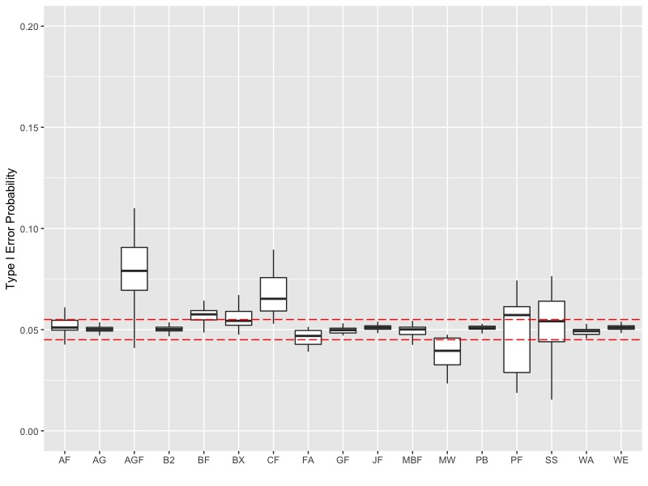

Figure 3: Type I error probability of the tests for $k=3$.

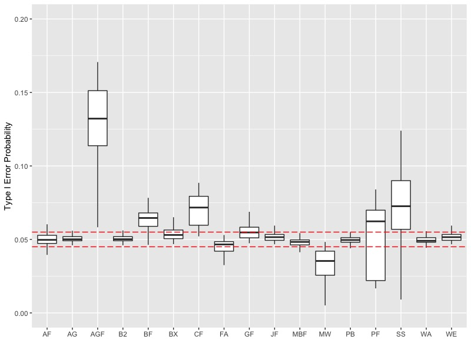

Figure 4: Type I error probability of the tests for $k=5$.

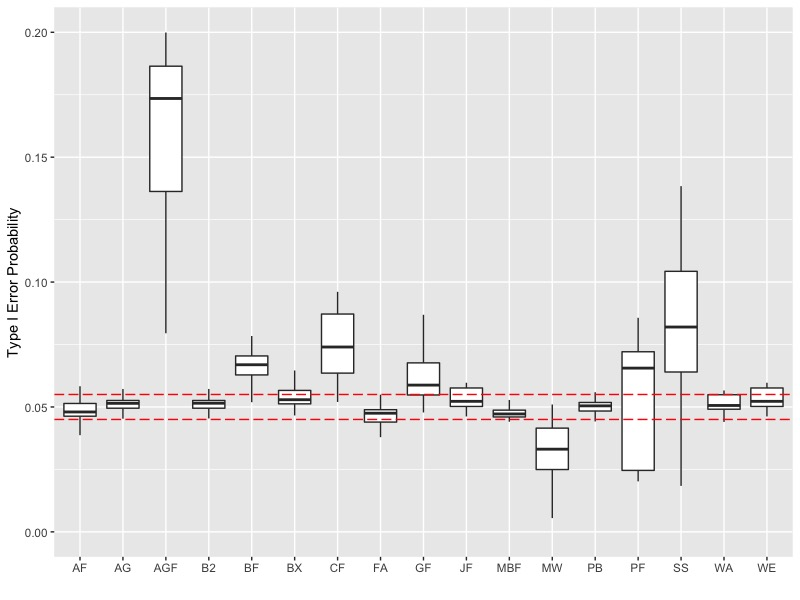

Figure 5: Type I error probability of the tests for $k=7$.

## The results of the penalized powers

In this section, the penalized power results are given under four configuration factors are sample size, design type, effect size, heteroscedasticity level for $k=3, 5, 7$. The samples follows normal distribution with the parameters $(\mu_i, \sigma_i^2)$ as given in Tables 1, 2, 3. The mean parameter of the samples are shown as the effect size $\Delta_i$ in each line. This means that the mean parameter of the samples are zero except the last sample is $\Delta_i$.

The AF and MBF test are superior than others in most of the scenarios. In the lower level of heteroscedasticity for all sample sizes, the penalized power of the tests are higher than 0.90 for $k=3$. It is the same situation for $k=5$ except for a small sample-unbalanced design. In this case, the penalized power of the AF and MGF is close to the 0.90, and the performance of the others is unacceptable. For $k=7$, the penalized power of the tests is higher than 0.90 except for small sample-lower heteroscedasticity scenarios. In this case, the AF and MBF tests show acceptable performance in terms of penalized power in only small sample-lower level heteroscedasticity. As a result, it is clearly seen that the penalized power of the tests decreases dramatically in the higher level of heteroscedasticity for $k=5, 7$.

Table 1: Penalized powers for $k=3$

| $n_i$ | $\sigma_i^2$ | $\Delta_i$ | AG | AF | B2 | GF | JF | MBF | PB | WE | WA |
| --- | --- | --- | --- | --- | --- | --- | --- | --- | --- | --- | --- |
| (10, 10, 10) | (0.1, 0.2, 0.3) | 0.3 | 0.2232 | 0.2630 | 0.2236 | 0.2133 | 0.2314 | 0.2628 | 0.2306 | 0.2314 | 0.2128 |
|  |  | 0.8 | 0.9045 | 0.9391 | 0.9047 | 0.8915 | 0.9197 | 0.9390 | 0.9201 | 0.9197 | 0.8833 |
|  |  | 1.5 | 0.9910 | 0.9815 | 0.9911 | 0.9768 | 0.9921 | 0.9815 | 0.9941 | 0.9921 | 0.9614 |
|  | (0.1, 0.4, 0.7) | 0.3 | 0.1265 | 0.1491 | 0.1269 | 0.1277 | 0.1326 | 0.1490 | 0.1296 | 0.1326 | 0.1193 |
|  |  | 0.8 | 0.5962 | 0.6858 | 0.5978 | 0.6004 | 0.6129 | 0.6855 | 0.6089 | 0.6129 | 0.5829 |
|  |  | 1.5 | 0.9853 | 0.9880 | 0.9881 | 0.9893 | 0.9812 | 0.9879 | 0.9777 | 0.9812 | 0.9583 |
|  | (1, 2, 3) | 0.3 | 0.0682 | 0.0656 | 0.0684 | 0.0649 | 0.0708 | 0.0655 | 0.0702 | 0.0708 | 0.0644 |
|  |  | 0.8 | 0.1700 | 0.2006 | 0.1701 | 0.1653 | 0.1760 | 0.2004 | 0.1752 | 0.1760 | 0.1615 |
|  |  | 1.5 | 0.4832 | 0.5536 | 0.4833 | 0.4716 | 0.4998 | 0.5534 | 0.4968 | 0.4998 | 0.4693 |
|  | (1, 4, 7) | 0.3 | 0.0614 | 0.0566 | 0.0616 | 0.0622 | 0.0627 | 0.0565 | 0.0622 | 0.0627 | 0.0563 |
|  |  | 0.8 | 0.1023 | 0.1200 | 0.1026 | 0.1050 | 0.1075 | 0.1200 | 0.1068 | 0.1075 | 0.0958 |
|  |  | 1.5 | 0.2542 | 0.3022 | 0.2550 | 0.2556 | 0.2655 | 0.3021 | 0.2594 | 0.2655 | 0.2424 |
| (30, 30, 30) | (0.1, 0.2, 0.3) | 0.3 | 0.6299 | 0.7004 | 0.6293 | 0.6281 | 0.6327 | 0.7002 | 0.6342 | 0.6327 | 0.6375 |
|  |  | 0.8 | 0.9882 | 0.9980 | 0.9872 | 0.9872 | 0.9815 | 0.9979 | 0.9853 | 0.9815 | 0.9970 |
|  |  | 1.5 | 1 | 1 | 1 | 1 | 1 | 1 | 1 | 1 | 1 |
|  | (0.1, 0.4, 0.7) | 0.3 | 0.3210 | 0.3791 | 0.3212 | 0.3210 | 0.3243 | 0.3789 | 0.3224 | 0.3243 | 0.3233 |
|  |  | 0.8 | 0.9772 | 0.9924 | 0.9775 | 0.9779 | 0.9740 | 0.9922 | 0.9726 | 0.9740 | 0.9898 |
|  |  | 1.5 | 0.9831 | 0.9960 | 0.9834 | 0.9834 | 0.9796 | 0.9960 | 0.9787 | 0.9796 | 0.9960 |
|  | (1, 2, 3) | 0.3 | 0.0923 | 0.1072 | 0.0922 | 0.0934 | 0.0938 | 0.1070 | 0.0930 | 0.0938 | 0.0925 |
|  |  | 0.8 | 0.4785 | 0.5411 | 0.4780 | 0.4733 | 0.4823 | 0.5410 | 0.4789 | 0.4823 | 0.4820 |
|  |  | 1.5 | 0.9566 | 0.9798 | 0.9557 | 0.9545 | 0.9517 | 0.9797 | 0.9566 | 0.9517 | 0.9653 |
|  | (1, 4, 7) | 0.3 | 0.0661 | 0.0715 | 0.0663 | 0.0663 | 0.0672 | 0.0714 | 0.0648 | 0.0672 | 0.0657 |
|  |  | 0.8 | 0.2282 | 0.2809 | 0.2285 | 0.2284 | 0.2318 | 0.2808 | 0.2298 | 0.2318 | 0.2301 |
|  |  | 1.5 | 0.6982 | 0.7659 | 0.6990 | 0.7012 | 0.7032 | 0.7655 | 0.7009 | 0.7032 | 0.7100 |
| (50, 50, 50) | (0.1, 0.2, 0.3) | 0.3 | 0.8573 | 0.9046 | 0.8577 | 0.8546 | 0.8547 | 0.9045 | 0.8604 | 0.8547 | 0.8593 |
|  |  | 0.8 | 0.9811 | 0.9980 | 0.9815 | 0.9825 | 0.9759 | 0.9979 | 0.9853 | 0.9759 | 0.9834 |
|  |  | 1.5 | 1 | 1 | 1 | 1 | 1 | 1 | 1 | 1 | 1 |
|  | (0.1, 0.4, 0.7) | 0.3 | 0.5427 | 0.6028 | 0.5425 | 0.5443 | 0.5418 | 0.6026 | 0.5400 | 0.5418 | 0.5442 |
|  |  | 0.8 | 0.9832 | 0.9980 | 0.9834 | 0.9880 | 0.9759 | 0.9980 | 0.9740 | 0.9759 | 0.9872 |
|  |  | 1.5 | 1 | 1 | 1 | 1 | 0.9979 | 1 | 0.9940 | 0.9981 | 1 |
|  | (1, 2, 3) | 0.3 | 0.1421 | 0.1671 | 0.1431 | 0.1432 | 0.1435 | 0.1671 | 0.1474 | 0.1435 | 0.1434 |
|  |  | 0.8 | 0.7210 | 0.7900 | 0.7214 | 0.7203 | 0.7204 | 0.7900 | 0.7262 | 0.7204 | 0.7232 |
|  |  | 1.5 | 0.9803 | 0.9974 | 0.9807 | 0.9817 | 0.9751 | 0.9974 | 0.9843 | 0.9751 | 0.9826 |
|  | (1, 4, 7) | 0.3 | 0.0912 | 0.1040 | 0.0917 | 0.0907 | 0.0917 | 0.1040 | 0.0918 | 0.0917 | 0.0904 |
|  |  | 0.8 | 0.4020 | 0.4659 | 0.4018 | 0.4066 | 0.4017 | 0.4659 | 0.4021 | 0.4017 | 0.4032 |
|  |  | 1.5 | 0.9031 | 0.9405 | 0.9032 | 0.9070 | 0.8990 | 0.9405 | 0.8932 | 0.8990 | 0.9077 |
| (5, 10, 15) | (0.1, 0.2, 0.3) | 0.3 | 0.2790 | 0.3346 | 0.2791 | 0.2535 | 0.2573 | 0.2974 | 0.2605 | 0.2573 | 0.2371 |
|  |  | 0.8 | 0.9598 | 0.9388 | 0.9570 | 0.9217 | 0.9432 | 0.9342 | 0.9484 | 0.9432 | 0.9406 |
|  |  | 1.5 | 0.9844 | 0.9483 | 0.9815 | 0.9475 | 0.9731 | 0.9500 | 0.9787 | 0.9731 | 0.9759 |
|  | (0.1, 0.4, 0.7) | 0.3 | 0.1522 | 0.1955 | 0.1526 | 0.1346 | 0.1494 | 0.1743 | 0.1490 | 0.1494 | 0.1339 |
|  |  | 0.8 | 0.7601 | 0.8070 | 0.7609 | 0.7018 | 0.7535 | 0.7860 | 0.7532 | 0.7535 | 0.7063 |
|  |  | 1.5 | 0.9910 | 0.9612 | 0.9913 | 0.9340 | 0.9962 | 0.9748 | 0.9992 | 0.9962 | 0.9567 |
|  | (1, 2, 3) | 0.3 | 0.0702 | 0.0835 | 0.0709 | 0.0604 | 0.0650 | 0.0669 | 0.0652 | 0.0650 | 0.0607 |
|  |  | 0.8 | 0.2018 | 0.2644 | 0.2014 | 0.1817 | 0.1900 | 0.2236 | 0.1912 | 0.1900 | 0.1741 |
|  |  | 1.5 | 0.5940 | 0.6651 | 0.5928 | 0.5571 | 0.5611 | 0.6205 | 0.5649 | 0.5611 | 0.5412 |
|  | (1, 4, 7) | 0.3 | 0.0562 | 0.0690 | 0.0567 | 0.0460 | 0.0568 | 0.0610 | 0.0580 | 0.0568 | 0.0496 |
|  |  | 0.8 | 0.1202 | 0.1546 | 0.1210 | 0.1068 | 0.1190 | 0.1353 | 0.1190 | 0.1190 | 0.1036 |
|  |  | 1.5 | 0.3310 | 0.3986 | 0.3312 | 0.3016 | 0.3252 | 0.3689 | 0.3250 | 0.3252 | 0.2971 |
| (20, 30, 40) | (0.1, 0.2, 0.3) | 0.3 | 0.7142 | 0.7419 | 0.7143 | 0.7108 | 0.7071 | 0.7609 | 0.7093 | 0.7071 | 0.7068 |
|  |  | 0.8 | 0.9955 | 0.9509 | 0.9960 | 0.9980 | 0.9872 | 0.9970 | 0.9921 | 0.9872 | 0.9960 |
|  |  | 1.5 | 1 | 1 | 1 | 1 | 1 | 1 | 1 | 1 | 1 |
|  | (0.1, 0.4, 0.7) | 0.3 | 0.3951 | 0.4407 | 0.3953 | 0.3944 | 0.3994 | 0.4314 | 0.3953 | 0.3994 | 0.3872 |
|  |  | 0.8 | 0.9892 | 0.9612 | 0.9895 | 0.9936 | 0.9984 | 0.9869 | 0.9899 | 0.9984 | 0.9857 |
|  |  | 1.5 | 0.9910 | 0.9614 | 0.9911 | 0.9950 | 1 | 0.9872 | 0.9911 | 1 | 0.9872 |
|  | (1, 2, 3) | 0.3 | 0.1062 | 0.1227 | 0.1066 | 0.1022 | 0.1060 | 0.1196 | 0.1058 | 0.1060 | 0.1044 |
|  |  | 0.8 | 0.5572 | 0.5975 | 0.5576 | 0.5541 | 0.5521 | 0.6064 | 0.5540 | 0.5521 | 0.5530 |
|  |  | 1.5 | 0.9843 | 0.9452 | 0.9847 | 0.9860 | 0.9758 | 0.9892 | 0.9806 | 0.9758 | 0.9845 |
|  | (1, 4, 7) | 0.3 | 0.0743 | 0.0821 | 0.0747 | 0.0732 | 0.0756 | 0.0772 | 0.0747 | 0.0756 | 0.0735 |
|  |  | 0.8 | 0.2872 | 0.3234 | 0.2874 | 0.2876 | 0.2904 | 0.3157 | 0.2908 | 0.2904 | 0.2843 |
|  |  | 1.5 | 0.8011 | 0.8166 | 0.8020 | 0.8044 | 0.8100 | 0.8240 | 0.8004 | 0.8100 | 0.7957 |
| (25, 50, 75) | (0.1, 0.2, 0.3) | 0.3 | 0.9182 | 0.8505 | 0.9184 | 0.9294 | 0.9129 | 0.9361 | 0.9153 | 0.9129 | 0.9227 |
|  |  | 0.8 | 0.9744 | 0.8811 | 0.9750 | 0.9872 | 0.9704 | 0.9796 | 0.9750 | 0.9704 | 0.9825 |
|  |  | 1.5 | 1 | 1 | 1 | 1 | 1 | 1 | 1 | 1 | 1 |
|  | (0.1, 0.4, 0.7) | 0.3 | 0.6392 | 0.6680 | 0.6398 | 0.6375 | 0.6365 | 0.6702 | 0.6384 | 0.6365 | 0.6380 |
|  |  | 0.8 | 0.9682 | 0.9054 | 0.9685 | 0.9704 | 0.9649 | 0.9631 | 0.9750 | 0.9649 | 0.9722 |
|  |  | 1.5 | 1 | 0.9654 | 1 | 1 | 1 | 1 | 1 | 1 | 1 |
|  | (1, 2, 3) | 0.3 | 0.1631 | 0.2058 | 0.1636 | 0.1649 | 0.1630 | 0.1932 | 0.1652 | 0.1630 | 0.1627 |
|  |  | 0.8 | 0.8022 | 0.7839 | 0.8030 | 0.8105 | 0.7976 | 0.8452 | 0.7991 | 0.7976 | 0.8058 |
|  |  | 1.5 | 0.9745 | 0.8811 | 0.9750 | 0.9872 | 0.9704 | 0.9796 | 0.9750 | 0.9704 | 0.9825 |
|  | (1, 4, 7) | 0.3 | 0.0970 | 0.1217 | 0.0972 | 0.0959 | 0.0969 | 0.1094 | 0.0989 | 0.0969 | 0.0961 |
|  |  | 0.8 | 0.4922 | 0.5291 | 0.4924 | 0.4896 | 0.4902 | 0.5205 | 0.4941 | 0.4902 | 0.4900 |
|  |  | 1.5 | 0.9466 | 0.8923 | 0.9470 | 0.9486 | 0.9433 | 0.9435 | 0.9531 | 0.9433 | 0.9500 |

Table 2: Penalized powers for $k=5$

| $n_i$ | $\sigma_i^2$ | $\Delta_i$ | AG | AF | B2 | JF | MBF | PB | WE | WA |
| --- | --- | --- | --- | --- | --- | --- | --- | --- | --- | --- |
| (10, 10, 10, 10, 10) | (0.1, 0.2, 0.3, 0.4, 0.5) | 0.3 | 0.0713 | 0.0867 | 0.0716 | 0.0779 | 0.0863 | 0.0729 | 0.0779 | 0.0718 |
|  |  | 0.8 | 0.2172 | 0.3403 | 0.2173 | 0.2424 | 0.3400 | 0.2350 | 0.2424 | 0.2271 |
|  |  | 1.5 | 0.6316 | 0.8549 | 0.6315 | 0.6984 | 0.8542 | 0.6897 | 0.6984 | 0.6722 |
|  | (0.1, 0.4, 0.7, 1.1, 1.5) | 0.3 | 0.0562 | 0.0586 | 0.0565 | 0.0543 | 0.0536 | 0.0540 | 0.0543 | 0.0515 |
|  |  | 0.8 | 0.0917 | 0.1191 | 0.0915 | 0.0848 | 0.1074 | 0.0843 | 0.0848 | 0.0791 |
|  |  | 1.5 | 0.2110 | 0.3094 | 0.2109 | 0.1840 | 0.2835 | 0.1850 | 0.1840 | 0.1747 |
|  | (1, 2, 3, 4, 5) | 0.3 | 0.0522 | 0.0541 | 0.0523 | 0.0560 | 0.0540 | 0.0525 | 0.0560 | 0.0502 |
|  |  | 0.8 | 0.0658 | 0.0788 | 0.0657 | 0.0713 | 0.0785 | 0.0671 | 0.0713 | 0.0647 |
|  |  | 1.5 | 0.1066 | 0.5250 | 0.1065 | 0.1165 | 0.1479 | 0.1072 | 0.1165 | 0.1046 |
|  | (1, 4, 7, 11, 15) | 0.3 | 0.0953 | 0.1154 | 0.0951 | 0.0923 | 0.1153 | 0.0964 | 0.0923 | 0.0940 |
|  |  | 0.8 | 0.4644 | 0.5647 | 0.4635 | 0.4510 | 0.5645 | 0.4635 | 0.4510 | 0.4611 |
|  |  | 1.5 | 0.9652 | 0.9788 | 0.9633 | 0.9312 | 0.9785 | 0.9611 | 0.9312 | 0.9563 |
| (30, 30, 30, 30, 30) | (0.1, 0.2, 0.3, 0.4, 0.5) | 0.3 | 0.3557 | 0.4704 | 0.3556 | 0.3598 | 0.4700 | 0.3573 | 0.3598 | 0.3601 |
|  |  | 0.8 | 0.9824 | 0.9871 | 0.9824 | 0.9666 | 0.9870 | 0.9716 | 0.9666 | 0.9803 |
|  |  | 1.5 | 0.9834 | 0.9872 | 0.9844 | 0.9676 | 0.9871 | 0.9731 | 0.9676 | 0.9815 |
|  | (0.1, 0.4, 0.7, 1.1, 1.5) | 0.3 | 0.1442 | 0.1996 | 0.1443 | 0.1461 | 0.1994 | 0.1445 | 0.1461 | 0.1456 |
|  |  | 0.8 | 0.7418 | 0.8700 | 0.7420 | 0.7478 | 0.8700 | 0.7439 | 0.7478 | 0.7586 |
|  |  | 1.5 | 0.9843 | 0.9931 | 0.9848 | 0.9708 | 0.9930 | 0.9700 | 0.9708 | 0.9906 |
|  | (1, 2, 3, 4, 5) | 0.3 | 0.0773 | 0.0898 | 0.0779 | 0.0791 | 0.0893 | 0.0784 | 0.0791 | 0.0768 |
|  |  | 0.8 | 0.2581 | 0.3510 | 0.2590 | 0.2618 | 0.3508 | 0.2606 | 0.2618 | 0.2614 |
|  |  | 1.5 | 0.7472 | 0.8595 | 0.7477 | 0.7509 | 0.8593 | 0.7537 | 0.7509 | 0.7579 |
|  | (1, 4, 7, 11, 15) | 0.3 | 0.0621 | 0.0666 | 0.0622 | 0.0621 | 0.0664 | 0.0624 | 0.0621 | 0.0614 |
|  |  | 0.8 | 0.1158 | 0.1557 | 0.1160 | 0.1167 | 0.1552 | 0.1164 | 0.1167 | 0.1159 |
|  |  | 1.5 | 0.3113 | 0.4370 | 0.3112 | 0.3182 | 0.4366 | 0.3153 | 0.3182 | 0.3193 |
| (50, 50, 50, 50, 50) | (0.1, 0.2, 0.3, 0.4, 0.5) | 0.3 | 0.5882 | 0.6978 | 0.5883 | 0.5996 | 0.6975 | 0.5964 | 0.5996 | 0.5881 |
|  |  | 0.8 | 0.9955 | 0.9825 | 0.9960 | 1 | 0.9823 | 0.9990 | 1 | 0.9901 |
|  |  | 1.5 | 1 | 1 | 1 | 1 | 1 | 1 | 1 | 1 |
|  | (0.1, 0.4, 0.7, 1.1, 1.5) | 0.3 | 0.2161 | 0.3051 | 0.2163 | 0.2215 | 0.3050 | 0.2178 | 0.2215 | 0.2152 |
|  |  | 0.8 | 0.9432 | 0.9636 | 0.9433 | 0.9472 | 0.9633 | 0.9440 | 0.9472 | 0.9321 |
|  |  | 1.5 | 0.9890 | 0.9787 | 0.9892 | 0.9901 | 0.9785 | 0.9872 | 0.9901 | 0.9750 |
|  | (1, 2, 3, 4, 5) | 0.3 | 0.0912 | 0.1121 | 0.0919 | 0.0929 | 0.1120 | 0.0921 | 0.0929 | 0.0909 |
|  |  | 0.8 | 0.4361 | 0.5477 | 0.4363 | 0.4465 | 0.5474 | 0.4435 | 0.4465 | 0.4374 |
|  |  | 1.5 | 0.9502 | 0.9665 | 0.9508 | 0.9574 | 0.9663 | 0.9558 | 0.9574 | 0.9473 |
|  | (1, 4, 7, 11, 15) | 0.3 | 0.0621 | 0.0701 | 0.0628 | 0.0626 | 0.0700 | 0.0621 | 0.0626 | 0.0610 |
|  |  | 0.8 | 0.1617 | 0.2248 | 0.1619 | 0.1657 | 0.2245 | 0.1624 | 0.1657 | 0.1602 |
|  |  | 1.5 | 0.5205 | 0.6456 | 0.5206 | 0.5292 | 0.6455 | 0.5302 | 0.5292 | 0.5197 |
| (4, 6, 10, 14, 16) | (0.1, 0.2, 0.3, 0.4, 0.5) | 0.3 | 0.1680 | 0.2295 | 0.1682 | 0.1448 | 0.1922 | 0.1309 | 0.1448 | 0.1313 |
|  |  | 0.8 | 0.8345 | 0.9315 | 0.8335 | 0.7925 | 0.8584 | 0.7690 | 0.7925 | 0.7730 |
|  |  | 1.5 | 0.9833 | 0.9844 | 0.9814 | 0.9795 | 0.9198 | 0.9739 | 0.9795 | 0.9758 |
|  | (0.1, 0.4, 0.7, 1.1, 1.5) | 0.3 | 0.0848 | 0.1110 | 0.0847 | 0.0790 | 0.0988 | 0.0745 | 0.0790 | 0.0736 |
|  |  | 0.8 | 0.3790 | 0.5455 | 0.3790 | 0.3366 | 0.5029 | 0.3283 | 0.3366 | 0.3282 |
|  |  | 1.5 | 0.9103 | 0.9756 | 0.9072 | 0.8771 | 0.9474 | 0.8920 | 0.8771 | 0.8947 |
|  | (1, 2, 3, 4, 5) | 0.3 | 0.0633 | 0.0625 | 0.0632 | 0.0605 | 0.0501 | 0.0583 | 0.0605 | 0.0570 |
|  |  | 0.8 | 0.1252 | 0.1750 | 0.1253 | 0.1103 | 0.1469 | 0.1081 | 0.1103 | 0.1069 |
|  |  | 1.5 | 0.3671 | 0.5264 | 0.3674 | 0.3126 | 0.4614 | 0.3090 | 0.3126 | 0.3093 |
|  | (1, 4, 7, 11, 15) | 0.3 | 0.0523 | 0.0537 | 0.0525 | 0.0544 | 0.0471 | 0.0479 | 0.0544 | 0.0474 |
|  |  | 0.8 | 0.0727 | 0.0902 | 0.0735 | 0.0707 | 0.0791 | 0.0635 | 0.0707 | 0.0630 |
|  |  | 1.5 | 0.1466 | 0.2189 | 0.1475 | 0.1359 | 0.1930 | 0.1195 | 0.1359 | 0.1197 |
| (12,18, 30, 42, 48) | (0.1, 0.2, 0.3, 0.4, 0.5) | 0.3 | 0.5134 | 0.6239 | 0.5129 | 0.4915 | 0.6184 | 0.4904 | 0.4915 | 0.4905 |
|  |  | 0.8 | 0.9969 | 0.9466 | 0.9959 | 0.9824 | 0.9863 | 0.9910 | 0.9824 | 0.9959 |
|  |  | 1.5 | 1 | 1 | 1 | 1 | 1 | 1 | 1 | 1 |
|  | (0.1, 0.4, 0.7, 1.1, 1.5) | 0.3 | 0.1999 | 0.2816 | 0.2000 | 0.1936 | 0.2697 | 0.1906 | 0.1936 | 0.1904 |
|  |  | 0.8 | 0.9238 | 0.9291 | 0.9239 | 0.9091 | 0.9556 | 0.9046 | 0.9091 | 0.9183 |
|  |  | 1.5 | 0.9977 | 0.9543 | 0.9980 | 0.9853 | 0.9882 | 0.9815 | 0.9853 | 0.9980 |
|  | (1, 2, 3, 4, 5) | 0.3 | 0.0812 | 0.1162 | 0.0814 | 0.0817 | 0.1028 | 0.0804 | 0.0817 | 0.0772 |
|  |  | 0.8 | 0.3714 | 0.4900 | 0.3713 | 0.3630 | 0.4614 | 0.3567 | 0.3630 | 0.3459 |
|  |  | 1.5 | 0.9016 | 0.9321 | 0.9017 | 0.9085 | 0.9309 | 0.8963 | 0.9085 | 0.8825 |
|  | (1, 4, 7, 11, 15) | 0.3 | 0.0611 | 0.0718 | 0.0618 | 0.0615 | 0.0670 | 0.0605 | 0.0615 | 0.0607 |
|  |  | 0.8 | 0.1502 | 0.2101 | 0.1506 | 0.1445 | 0.2032 | 0.1460 | 0.1445 | 0.1443 |
|  |  | 1.5 | 0.4561 | 0.5788 | 0.4561 | 0.4425 | 0.5779 | 0.4465 | 0.4425 | 0.4472 |
| (20, 30, 50, 70, 80) | (0.1, 0.2, 0.3, 0.4, 0.5) | 0.3 | 0.7441 | 0.8321 | 0.7448 | 0.7426 | 0.8292 | 0.7403 | 0.7426 | 0.7293 |
|  |  | 0.8 | 0.9692 | 0.9509 | 0.9695 | 0.9759 | 0.9722 | 0.9731 | 0.9759 | 0.9614 |
|  |  | 1.5 | 0.9891 | 0.9729 | 0.9895 | 0.9959 | 0.9822 | 0.9921 | 0.9899 | 0.9934 |
|  | (0.1, 0.4, 0.7, 1.1, 1.5) | 0.3 | 0.7590 | 0.8306 | 0.7593 | 0.7602 | 0.8469 | 0.7569 | 0.7602 | 0.7499 |
|  |  | 0.8 | 0.9782 | 0.9444 | 0.9785 | 0.9844 | 0.9874 | 0.9828 | 0.9844 | 0.9747 |
|  |  | 1.5 | 0.9821 | 0.9449 | 0.9825 | 0.9882 | 0.9882 | 0.9872 | 0.9882 | 0.9787 |
|  | (1, 2, 3, 4, 5) | 0.3 | 0.1040 | 0.1441 | 0.1047 | 0.1027 | 0.1374 | 0.1018 | 0.1027 | 0.1008 |
|  |  | 0.8 | 0.5771 | 0.6735 | 0.5773 | 0.5709 | 0.7017 | 0.5684 | 0.5709 | 0.5719 |
|  |  | 1.5 | 0.9472 | 0.9101 | 0.9475 | 0.9473 | 0.9861 | 0.9499 | 0.9473 | 0.9550 |
|  | (1, 4, 7, 11, 15) | 0.3 | 0.0651 | 0.0805 | 0.0657 | 0.0654 | 0.0765 | 0.0652 | 0.0654 | 0.0643 |
|  |  | 0.8 | 0.2322 | 0.3155 | 0.2326 | 0.2275 | 0.3055 | 0.2278 | 0.2275 | 0.2250 |
|  |  | 1.5 | 0.7033 | 0.7689 | 0.7038 | 0.6962 | 0.7887 | 0.6987 | 0.6962 | 0.6995 |

Table 3: Penalized powers for $k=7$

| $n_i$ | $\sigma_i^2$ | $\Delta_i$ | AG | AF | B2 | MBF | PB | WA |
| --- | --- | --- | --- | --- | --- | --- | --- | --- |
| (10, 10, 10, 10, 10, 10, 10) | (0.1, 0.2, 0.3, 0.4, 0.5, 0.6, 0.7) | 0.3 | 0.0916 | 0.1176 | 0.0921 | 0.1175 | 0.0954 | 0.0960 |
|  |  | 0.8 | 0.3745 | 0.6158 | 0.3750 | 0.6154 | 0.4288 | 0.4279 |
|  |  | 1.5 | 0.8713 | 0.9725 | 0.8715 | 0.9723 | 0.9247 | 0.9068 |
|  | (0.1, 0.4, 0.7, 1.1, 1.5, 1.9, 2.3) | 0.3 | 0.0668 | 0.0655 | 0.0666 | 0,0651 | 0.0660 | 0.0658 |
|  |  | 0.8 | 0.1501 | 0.2255 | 0.1502 | 0.2253 | 0.1578 | 0.1603 |
|  |  | 1.5 | 0.4021 | 0.6756 | 0.4023 | 0.6753 | 0.4519 | 0.4519 |
|  | (1, 2, 3, 4, 5, 6, 7) | 0.3 | 0.0565 | 0.0520 | 0.0568 | 0.0520 | 0.0597 | 0.0588 |
|  |  | 0.8 | 0.0819 | 0.0944 | 0.0820 | 0.0942 | 0.0831 | 0.0834 |
|  |  | 1.5 | 0.1612 | 0.2385 | 0.1609 | 0.2381 | 0.1693 | 0.1695 |
|  | (1, 4, 7, 11, 15, 19, 23) | 0.3 | 0.0560 | 0.0485 | 0.0561 | 0.0483 | 0.0577 | 0.0570 |
|  |  | 0.8 | 0.0632 | 0.0608 | 0.0635 | 0.0604 | 0.0625 | 0.0633 |
|  |  | 1.5 | 0.0855 | 0.1044 | 0.0858 | 0.1042 | 0.0860 | 0.0880 |
| (30, 30, 30, 30, 30, 30, 30) | (0.1, 0.2, 0.3, 0.4, 0.5, 0.6, 0.7) | 0.3 | 0.2204 | 0.3303 | 0.2209 | 0.3301 | 0.2301 | 0.2298 |
|  |  | 0.8 | 0.9598 | 0.9703 | 0.9596 | 0.9701 | 0.9616 | 0.9640 |
|  |  | 1.5 | 0.9957 | 0.9778 | 0.9960 | 0.9768 | 0.9911 | 0.9941 |
|  | (0.1, 0.4, 0.7, 1.1, 1.5, 1.9, 2.3) | 0.3 | 0.0978 | 0.1334 | 0.0980 | 0.1324 | 0.0977 | 0.0985 |
|  |  | 0.8 | 0.4679 | 0.6533 | 0.4680 | 0.6530 | 0.4867 | 0.4904 |
|  |  | 1.5 | 0.9702 | 0.9822 | 0.9704 | 0.9820 | 0.9630 | 0.9757 |
|  | (1, 2, 3, 4, 5, 6, 7) | 0.3 | 0.0651 | 0.0712 | 0.0657 | 0.0711 | 0.0670 | 0.0636 |
|  |  | 0.8 | 0.1652 | 0.2417 | 0.1657 | 0.2414 | 0.1725 | 0.1706 |
|  |  | 1.5 | 0.5243 | 0.6901 | 0.5247 | 0.6900 | 0.5453 | 0.5461 |
|  | (1, 4, 7, 11, 15, 19, 23) | 0.3 | 0.0552 | 0.0575 | 0.0555 | 0.0572 | 0.0550 | 0.0537 |
|  |  | 0.8 | 0.0852 | 0.1060 | 0.0857 | 0.1050 | 0.0853 | 0.0860 |
|  |  | 1.5 | 0.1810 | 0.2765 | 0.1813 | 0.2755 | 0.1841 | 0.1839 |
| (50, 50, 50, 50, 50, 50, 50) | (0.1, 0.2, 0.3, 0.4, 0.5, 0.6, 0.7) | 0.3 | 0.3722 | 0.5118 | 0.3725 | 0.5111 | 0.3782 | 0.3787 |
|  |  | 0.8 | 0.9969 | 0.9853 | 0.9978 | 0.9850 | 0.9988 | 0.9948 |
|  |  | 1.5 | 1 | 1 | 1 | 1 | 1 | 1 |
|  | (0.1, 0.4, 0.7, 1.1, 1.5, 1.9, 2.3) | 0.3 | 0.1362 | 0.1907 | 0.1365 | 0.1907 | 0.1387 | 0.1380 |
|  |  | 0.8 | 0.7502 | 0.8843 | 0.7507 | 0.8840 | 0.7686 | 0.7657 |
|  |  | 1.5 | 0.9943 | 0.9863 | 0.9948 | 0.9852 | 0.9988 | 0.9968 |
|  | (1, 2, 3, 4, 5, 6, 7) | 0.3 | 0.0762 | 0.0914 | 0.0764 | 0.0910 | 0.0787 | 0.0758 |
|  |  | 0.8 | 0.2660 | 0.3817 | 0.2661 | 0.3812 | 0.2739 | 0.2697 |
|  |  | 1.5 | 0.8052 | 0.9063 | 0.8058 | 0.9051 | 0.8202 | 0.8145 |
|  | (1, 4, 7, 11, 15, 19, 23) | 0.3 | 0.0600 | 0.0629 | 0.0601 | 0.0612 | 0.0605 | 0.0594 |
|  |  | 0.8 | 0.1093 | 0.1499 | 0.1099 | 0.1479 | 0.1123 | 0.1099 |
|  |  | 1.5 | 0.2902 | 0.4275 | 0.2906 | 0.4271 | 0.2981 | 0.2971 |
| (4, 6, 8, 10, 12, 14, 16) | (0.1, 0.2, 0.3, 0.4, 0.5, 0.6, 0.7) | 0.3 | 0.1201 | 0.1540 | 0.1208 | 0.1419 | 0.1025 | 0.1067 |
|  |  | 0.8 | 0.6065 | 0.7846 | 0.6068 | 0.7525 | 0.5561 | 0.5596 |
|  |  | 1.5 | 0.9622 | 0.9456 | 0.9617 | 0.9273 | 0.9852 | 0.9544 |
|  | (0.1, 0.4, 0.7, 1.1, 1.5, 1.9, 2.3) | 0.3 | 0.0718 | 0.0814 | 0.0720 | 0.0750 | 0.0629 | 0.0704 |
|  |  | 0.8 | 0.2169 | 0.3329 | 0.2173 | 0.3132 | 0.1798 | 0.1944 |
|  |  | 1.5 | 0.6726 | 0.8591 | 0.6734 | 0.8274 | 0.6240 | 0.6532 |
|  | (1, 2, 3, 4, 5, 6, 7) | 0.3 | 0.0622 | 0.0549 | 0.0621 | 0.0509 | 0.0587 | 0.0609 |
|  |  | 0.8 | 0.1035 | 0.1204 | 0.1041 | 0.1114 | 0.0856 | 0.0900 |
|  |  | 1.5 | 0.2357 | 0.3452 | 0.2356 | 0.3250 | 0.1935 | 0.2023 |
|  | (1, 4, 7, 11, 15, 19, 23) | 0.3 | 0.0561 | 0.0497 | 0.0564 | 0.0481 | 0.0518 | 0.0563 |
|  |  | 0.8 | 0.0653 | 0.0714 | 0.0654 | 0.0677 | 0.0607 | 0.0641 |
|  |  | 1.5 | 0.1078 | 0.1385 | 0.1080 | 0.1305 | 0.0939 | 0.0947 |
| (12, 18, 24, 30, 36, 42, 48) | (0.1, 0.2, 0.3, 0.4, 0.5, 0.6, 0.7) | 0.3 | 0.3332 | 0.4900 | 0.3336 | 0.4627 | 0.3226 | 0.3149 |
|  |  | 0.8 | 0.9737 | 0.9882 | 0.9740 | 0.9750 | 0.9798 | 0.9740 |
|  |  | 1.5 | 0.9950 | 1 | 0.9940 | 0.9920 | 0.9906 | 0.9912 |
|  | (0.1, 0.4, 0.7, 1.1, 1.5, 1.9, 2.3) | 0.3 | 0.1277 | 0.1966 | 0.1284 | 0.1814 | 0.1228 | 0.1205 |
|  |  | 0.8 | 0.7067 | 0.8465 | 0.7070 | 0.8059 | 0.6955 | 0.6979 |
|  |  | 1.5 | 0.9990 | 0.9970 | 0.9995 | 0.9649 | 0.9950 | 0.9988 |
|  | (1, 2, 3, 4, 5, 6, 7) | 0.3 | 0.0712 | 0.0870 | 0.0718 | 0.0798 | 0.0675 | 0.0678 |
|  |  | 0.8 | 0.2458 | 0.3612 | 0.2452 | 0.3438 | 0.2307 | 0.2322 |
|  |  | 1.5 | 0.7381 | 0.8667 | 0.7380 | 0.8494 | 0.7108 | 0.7255 |
|  | (1, 4, 7, 11, 15, 19, 23) | 0.3 | 0.0544 | 0.0636 | 0.0541 | 0.0593 | 0.0557 | 0.0530 |
|  |  | 0.8 | 0.0998 | 0.1537 | 0.0993 | 0.1388 | 0.0956 | 0.0938 |
|  |  | 1.5 | 0.2679 | 0.4137 | 0.2675 | 0.3839 | 0.2616 | 0.2539 |
| (20, 30, 40, 50, 60, 70, 80) | (0.1, 0.2, 0.3, 0.4, 0.5, 0.6, 0.7) | 0.3 | 0.5722 | 0.7108 | 0.5720 | 0.7148 | 0.5596 | 0.5577 |
|  |  | 0.8 | 0.9990 | 0.9614 | 0.9987 | 0.9911 | 0.9960 | 0.9980 |
|  |  | 1.5 | 1 | 0.9614 | 1 | 1 | 1 | 1 |
|  | (0.1, 0.4, 0.7, 1.1, 1.5, 1.9, 2.3) | 0.3 | 0.1939 | 0.2736 | 0.1935 | 0.2647 | 0.1885 | 0.1875 |
|  |  | 0.8 | 0.9270 | 0.9103 | 0.9262 | 0.9315 | 0.9254 | 0.9286 |
|  |  | 1.5 | 0.9921 | 0.9261 | 0.9919 | 0.9509 | 0.9901 | 0.9941 |
|  | (1, 2, 3, 4, 5, 6, 7) | 0.3 | 0.0835 | 0.1185 | 0.0832 | 0.1079 | 0.0834 | 0.0799 |
|  |  | 0.8 | 0.4142 | 0.5701 | 0.4140 | 0.5418 | 0.4040 | 0.4014 |
|  |  | 1.5 | 0.9426 | 0.9747 | 0.9423 | 0.9664 | 0.9433 | 0.9380 |
|  | (1, 4, 7, 11, 15, 19, 23) | 0.3 | 0.0551 | 0.0709 | 0.0542 | 0.0658 | 0.0563 | 0.0551 |
|  |  | 0.8 | 0.1388 | 0.2142 | 0.1369 | 0.2012 | 0.1352 | 0.1343 |
|  |  | 1.5 | 0.4446 | 0.6286 | 0.4442 | 0.6072 | 0.4363 | 0.4414 |

# Discussion

In this paper, an extensive Monte-Carlo simulation study is conducted to investigate the performance of the tests for equality of normal distributed and independent groups’ means under unequal variances under several scenarios. It is rather rare to encounter normally distributed data and (Bono et al. 2017) showed that the data obtained from health, educational, and social sciences research are often not normally distributed. (Blanca et al. 2013) discussed the negative effect of non-normality on the power and Type I error probability of the parametric tests. It is reality that the normality assumption is crucial for the considered tests in this study. Here, it is focused on the performance of the considered tests under normality to fill the gap mentioned the introduction part. Firstly, the ability of the test to control the Type I error probability is examined and the boxplots in Figs.3, 4 and 5 are used to summarize the results. The tests which can control the Type I error probability are obtained as robust tests with respect to the (Bradley 1978)’s limits. Then, the penalized power of the robust tests is calculated. The reason for using this method was to consider two possible types of error.

As a result of this study, the robust tests are obtained and can be used in most of the situations except for a higher level of heteroscedasticity and small sample sizes. Using the results of the simulation study, researchers can use appropriate tests for their studies.

# Summary and Future works

The [*doex*](https://CRAN.R-project.org/package=doex) package contains the several tests for testing equality of normally distributed groups’ means under unequal variances. Most of these tests are not available in any R package. Thus, we fill this gap by implementing the package in the statistical software literature. The fact that the package contains tests such as the GF, PB, and FA with complex calculation steps provides a significant benefit to multidisciplinary researchers. Furthermore, the performance of the considered tests is investigated under normal distributions in detail in an extensive Monte-Carlo simulation study. Considering the number of methods discussed, this article is the most comprehensive performance investigation study in the literature. Recommendations were made to the researchers by using the interesting outputs from the simulation study.

It is always optimistic idea to encountered normal distribution in real life. The performance of the considered tests can be also investigated under the various distributions or to focus the tests are proposed for non-normal distributions. Thus, it is planned to expand the package by adding methods used to test the equality of the log-normal (Tian and Wu 2007) and inverse-Gaussian (Tian 2006; Ma and Tian 2009) distributed and independent groups’ means in further studies.

# Acknowledgement

This study is supported by the Eskisehir Technical University Scientific Research Projects Commission under grant No. 20DRP047.

Aho, Ken. 2018. *Asbio: A Collection of Statistical Tools for Biologists*. https://CRAN.R-project.org/package=asbio.

Alexander, R. A., and D. M. Govern. 1994. “A New and Simplier Approximation for ANOVA Under Variance Heterogeneity.” *Journal of Educational Statistics* 19 (2): 91–101. https://www.jstor.org/stable/1165140.

Argac, D. 2004. “Testing for Homogeneity in a General One-Way Classification with Fixed Effects: Power Simulations and Comparative Study.” *Computational Statistics & Data Analysis* 44: 603–12. https://doi.org/10.1016/S0167-9473(02)00264-5.

Asiribo, O., and J. Gurland. 1990. “Coping with Variance Heterogeneity.” *Communications in Statistics-Theory and Methods* 19 (11): 4029–48. https://www.tandfonline.com/doi/abs/10.1080/03610929008830427.

Aspin, A. A. 1948. “Interval Estimates for Linear Combinations of Means.” *Biometrika* 35 (1): 276–85. https://www.jstor.org/stable/2332631.

Berry, K. J., and P. W. Mielke. 2002. “The Fisher-Pitman Permutation Test: An Attractive Alternative to the f Test.” *Psychological Reports* 90 (2): 495–502. https://www.ncbi.nlm.nih.gov/pubmed/12061589.

Blanca, M. J., J. Arnau, D. Lopez-Montiel, R. Bono, and R. Bendayan. 2013. “Skewness and Kurtosis in Real Data Samples.” *Methodology* 9: 78–84.

Bono, R., M. J. Blanca, J. Arnau, and J Gomez-Benito. 2017. “Non-Normal Distributions Commonly Used in Health, Education, and Social Sciences: A Systematic Review.” *Frontiers in Psychology* 8.

Box, G. E. P. 1954. “Some Theorems on Quadratic Forms Applied in the Study of Analysis of Variance Problems.” *Technometrics* 25 (2): 290–302. https://www.jstor.org/stable/pdf/2236731.pdf.

Bradley, J. V. 1978. “Robustness.” *British Journal of Mathematical and Statistical Psychology* 31: 144–52.

Brown, M. B., and A. B. Forsythe. 1974. “The Small Sample Behavior of Some Statistics Which Test the Equality of Several Means.” *Technometrics* 16 (1): 81–90. https://www.jstor.org/stable/pdf/1267501.pdf.

Cavus, Mustafa, Berna Yazici, and Ahmet Sezer. 2019. “Penalized Power Approach to Compare the Power of the Tests When Type i Error Probabilities Are Different.” *Communication in Statistics-Simulation and Computation*. https://doi.org/10.1080/03610918.2019.1588310.

Cavus, M., B. Yazici, and A. Sezer. 2017. “Modified Tests for Comparison of Group Means Under Heteroskedasticity and Non-Normality Caused by Outliers.” *Hacettepe Journal of Mathematics and Statistics* 46 (3): 493–510. http://www.hjms.hacettepe.edu.tr/uploads/f0746d40-4b55-41fb-9917-12f8f2f0a2e4.pdf.

———. 2018. “Analysing Regional Export Data by the Modified Generalized f-Test.” *International Journal of Economic and Administrative Studies*, 541–51. https://dergipark.org.tr/download/article-file/408447.

Cochran, W. G. 1937. “Problems Arising in the Analysis of a Series of Similar Experiments.” *Technometrics* 4 (1): 290–302. https://www.jstor.org/stable/pdf/2984123.pdf.

Dag, O., A. Dolgun, and N. M. Konar. 2018. “Onewaytests: An r Package for One-Way Tests in Independent Groups Designs.” *R Journal* 10 (1): 175–99. https://journal.r-project.org/archive/2018/RJ-2018-022/RJ-2018-022.pdf.

Erps, R. C., and K. Noguchi. 2019. “A Robust Test for Checking the Homogeneity of Variability Measures and Its Application to the Analysis of Implicit Attitudes.” *Journal of Educational and Behavioral Statistics* 45 (4): 403–25.

Fox, J., and S. Weisberg. 2019. *An r Companion to Applied Regression*. Third edition. Sage, Thousand Oaks CA.

Gamage, J., and S. Weerahandi. 1998. “Size Performance of Some Tests in One-Way ANOVA.” *Communications in Statistics-Computation and Simulation* 27 (3): 165–73. http://dx.doi.org/10.1080/03610919808813500.

Gastwirth, Joseph L., Yulia R. Gel, W. L. Wallace Hui, Vyacheslav Lyubchich, Weiwen Miao, and Kimihiro Noguchi. 2020. *Lawstat: Tools for Biostatistics, Public Policy, and Law*. https://CRAN.R-project.org/package=lawstat.

Gokpinar, E., and F. Gokpinar. 2012. “A Test Based on the Computational Approach for Equality of Means Under the Unequal Variance Assumption.” *Hacettepe Journal of Mathematics and Statistics* 41 (4): 605–13. http://www.hjms.hacettepe.edu.tr/uploads/0871d39b-039b-45fb-9b31-483cdde56ef7.pdf.

Hartung, J., D. Argac, and K. H. Makambi. 2002. “Small Sample Properties of Tests on Homogeneity in One-Way ANOVA and Meta-Analysis.” *Statistical Papers* 43 (2): 1139–45. https://link.springer.com/article/10.1007/s00362-002-0097-8.

Hebbali, Aravind. 2018. *Inferr: Inferential Statistics*. https://CRAN.R-project.org/package=inferr.

Hothorn, T., K. Hornik, M. A. van de Wiel, and A. Zeileis. 2008. “Lawstat: An r Package for Law, Public Policy and Biostatistics.” *Journal of Statistical Software* 28 (8): 1–23. https://doi.org/10.18637/jss.v028.i08.

Hui, W., Y. R. Gel, and G. G. Gastwirth. 2008. “Implementing a Class of Permutation Tests: The Coin Package.” *Journal of Statistical Software* 28 (3): 1–26. https://doi.org/10.18637/jss.v028.i03.

Johansen, S. 1980. “The Welch-James Approximation to the Distribution of the Residual Sum of Squares in a Weighted Linear Regression.” *Biometrika* 67 (1): 58–92. https://www.jstor.org/stable/2335320.

Kassambara, Alboukadel. 2020. *Rstatix: Pipe-Friendly Framework for Basic Statistical Tests*. https://CRAN.R-project.org/package=rstatix.

Krishnamoorthy, K., F. Lu, and T. Mathew. 2007. “A Parametric Bootstrap Approach for ANOVA with Unequal Variances: Fixed and Random Models.” *Computational Statistics and Data Analysis* 51 (12): 5731–42. https://www.sciencedirect.com/science/article/pii/S016794730600363X.

Lee, S., and C. H. Ahn. 2003. “Modified ANOVA for Unequal Variances.” *Communication in Statistics-Simulation and Computation* 32 (4): 987–1004.

Li, X., J. Wang, and H. Liang. 2011. “Comparison of Several Means: A Fiducial Based Approach.” *Computational Statistics and Data Analysis* 55 (5): 1993–2002. https://www.sciencedirect.com/science/article/pii/S0167947310004779.

Lloyd, C. J. 2005. “Estimating Test Power Adjusted for Size.” *Journal of Statistical Computation and Simulation* 75 (11): 921–33. https://www.tandfonline.com/doi/abs/10.1080/00949650412331321160.

Ma, C. X., and L. Tian. 2009. “A Parametric Bootstrap Approach for Testing Equality of Inverse Gaussian Means Under Heterogeneity.” *Communications in Statistics-Simulation and Computation* 38: 1153–60.

Mair, Patrick, and Rand Wilcox. 2018. *WRS2: Wilcox robust estimation and testing*.

Mehrotra, D. V. 1997. “Improving the Brown-Forsythe Solution to the Generalized Behrens-Fisher Problem.” *Communication in Statistics-Simulation and Computation* 26 (3): 1139–45. https://www.tandfonline.com/doi/abs/10.1080/03610919708813431.

Mutlu, H. T., F. Gokpinar, E. Gokpinar, H. H. Gul, and G. Guven. 2017. “A New Computational Approach Test for One-Way ANOVA Under Heteroscedasticity.” *Communications in Statistics - Theory and Methods* 46 (16): 8236–56.

Noguchi, K., and Y. R. Gel. 2010. “Combination of Levene-Type Tests and a Finite-Intersection Method for Testing Equality of Variances Against Ordered Alternatives.” *Journal of Nonparametric Statistics* 22 (7): 897–913.

Ozdemir, A. F., and S. Kurt. 2006. “One-Way Fixed Effect Analysis of Variance Under Variance Heterogeneity and a Solution Proposal.” *Selcuk Journal of Applied Mathematics* 7 (2): 81–90. http://sjam.selcuk.edu.tr/sjam/article/view/174.

Sadooghi-Alvandi, S. M., A. A. Jafari, and H. A. Mardani-Fard. 2012. “One-Way ANOVA with Unequal Variances.” *Communications in Statistics-Theory and Methods* 41 (22): 4200–4221. https://www.tandfonline.com/doi/full/10.1080/03610926.2011.573160.

Scott, A. J., and T. M. Smith. 1971. “Interval Estimates for Linear Combinations of Means.” *Journal of the Royal Statistical Society* 20 (3): 276–85. https://www.jstor.org/stable/2346757.

Tian, L. 2006. “Testing Equality of Inverse Gaussian Means Under Heterogeneity Based on Generalized Test Variable.” *Computational Statistics Data Analysis* 51: 1156:1162.

Tian, L., and J. Wu. 2007. “Inferences on the Common Mean of Several Log-Normal Populations: The Generalized Variable Approach.” *Biometrical Journal* 49: 944:951.

Villacorta, P. J. 2017. “The welchADF Package for Robust Hypothesis Testing in Unbalanced Multivariate Mixed Models with Heteroscedastic an Non-Normal Data.” *The R Journal* 9 (2): 309–28. https://journal.r-project.org/archive/2017/RJ-2017-049/RJ-2017-049.pdf.

Weerahandi, S. 1995. “ANOVA Under Unequal Error Variances.” *Biometrics* 51 (2): 589–99. http://www.jstor.org/stable/2532947.

Welch, B. L. 1951. “On the Comparison of Several Mean Values.” *Biometrika* 38 (1): 330–36. https://www.jstor.org/stable/2332631.

Zhang, J., and D. D. Boos. 1994. “Adjusted Power Estimates in Monte-Carlo Experiments.” *Communications in Statistics-Computation and Simulation* 23 (1): 165–73. https://www.tandfonline.com/doi/abs/10.1080/00949650412331321160.